# Quantile methods

### Alfred Galichon (NYU & Sciences Po)

## 'math+econ+code' masterclass on linear programming and economic applications

#### With python code examples

© 2018-2023 by Alfred Galichon. Past and present support from NSF grant DMS-1716489, ERC grant CoG-866274 are acknowledged, as well as inputs from contributors listed [here](http://www.math-econ-code.org/team).

**If you reuse material from this masterclass, please cite as:**  
Alfred Galichon, 'math+econ+code' masterclass on linear programming and economic applications. https://github.com/math-econ-code/mec_linprog

## References

- Koneker and Bassett (1978). `Regression quantile'. Econometrica.
- Koenker (2005). Quantile Regression. Cambridge University Press.
- Koenker, Roger and Kevin F. Hallock. “Quantile Regression”. Journal of Economic Perspectives, Volume 15, Number 4, Fall 2001, Pages 143–156

### What is the right definition of a quantile?

In dimension one, the following statements equivalently define quantiles of a distribution $Y\sim\nu$:

- The quantile map is the (generalized) inverse of the cdf of $\nu$: $F_{\nu}^{-1}$.
- The quantile map is the nondecreasing map $T$ such that if $U\sim\mathcal{U}\left( \left[ 0,1\right] \right) $, then $T\left( U\right) \sim\nu$.
- The quantile at $t$ $F_{\nu}^{-1}\left( t\right) $ is the solution of $\min_{q}\mathbb{E}\left[ \rho_{t}\left( Y-q\right) \right] $, where $\rho_{t}\left( z\right) =tz^{+}+\left( 1-t\right) z^{-}$.
- The quantile map is the solution to the Monge problem between distribution $\mathcal{U}\left( \left[ 0,1\right] \right) $ and $\nu$ relative to cost $\Phi\left( u,y\right) =uy$.

### Quantile: properties

Quantiles have a number of enjoyable properties that make them easy to work with.

- They fully characterize the distribution $\nu$.
- They allow to construct a representation of $\nu$: $F_{\nu}^{-1}\left( U\right) $, $U\sim\mu:=\mathcal{U}\left( \left[ 0,1\right] \right) $ has distribution $\nu$.
- They embed the median ($F_{\nu}^{-1}\left( 1/2\right) $) and the extreme values ($F_{\nu}^{-1}\left( 0\right) $ and $F_{\nu}^{-1}\left( 1\right) $).
- They allow to provide a construction of distance between distributions: for $p\geq1$,  
  $ \left( \int\left\vert F_{\nu}^{-1}\left( t\right) -F_{\nu}^{-1}\left( t\right) \right\vert ^{p}dt\right) ^{1/p} $  
  is the $p$-Wasserstein distance between $\mu$ and $\nu$.
- They allow for a natural construction of robust statistics by trimming the interval $\left[ 0,1\right] $.
- **They lend themselves to a natural notion of regression: quantile regression (Koenker and Bassett, 1978; Koenker 2005).**

### Quantile/quantile regression: applications

Quantiles are widely used in economics, finance and statistics.

- Comonotonicity: $\left( F_{\nu_{1}}^{-1}\left( U\right) ,F_{\nu_{2}% }^{-1}\left( U\right) \right) $ for $U\sim\mu:=\mathcal{U}\left( \left[ 0,1\right] \right) $ is a comonotone representation of $\nu_{1}$ and $\nu_{2}$.
- Mesures of risk: Value-at-risk $F_{\nu}^{-1}\left( 1-\alpha\right) $; CVaR $\int_{1-\alpha}^{1}F_{\nu}^{-1}\left( t\right) dt$.
- Non-expected utility: Yaari's rank-dependent EU (Choquet integral) $\int_{0}^{1}F_{\nu}^{-1}\left( t\right) w\left( t\right) dt$.
- Demand theory: Matzkin's identication of hedonic models.
- Income and inequality: Chamberlain (1994)'s study of the effect of unionization on wages.
- Biometrics: growth charts.

### What is quantile regression?

- Quantile regression therefore adopts a parameterization of the conditional quantile which is linear in $Z$. That is  
  $ Q_{Y|X}\left( \tau|x\right) =x^{\intercal}\beta_{\tau} $  
  (note that one can always augment $x$ with nonlinear functions of $x$, so this parameterization is quite general).
- In order to estimate $\beta_{\tau}$, first note that  
  $ Q_{Y|X}\left( \tau|x\right) =\arg\min_{q}\mathbb{E}\left[ \rho_{\tau }\left( Y-q\right) |X=x\right] $  
  where $\rho_{\tau}\left( w\right) =\tau w^{+}+\left( 1-\tau\right) w^{-}$.
- Therefore, if the conditional quantile has the specified form, $\beta_{u}$ is the solution to  
  $ \min_{\beta\in\mathbb{R}^{k}}\mathbb{E}\left[ \rho_{\tau}\left( Y-X^{\intercal}\beta\right) |X=x\right]$  
  for each $x$, and therefore it is the solution to the quantile regression problem introduced by Koenker and Bassett (1978)  
  $ \min_{\beta\in\mathbb{R}^{k}}\mathbb{E}\left[ \rho_{\tau}\left( Y-X^{\intercal}\beta\right) \right] . $

### Quantile regression as linear programming

- Koenker and Bassett showed that this problem has a linear programming formulation. Indeed, consider its sample version  
  $\min_{\beta\in\mathbb{R}^{k}}\sum_{i=1}^{n}\rho_{\tau}\left( Y_{i}% -X_{i}^{\intercal}\beta\right)$
- Introducing $Y_{i}-X_{i}^{\intercal}\beta=P_{i}-N_{i}$ with $P_{i},N_{i}\geq0$, we have  
  $ \begin{array} ~ \min_{\substack{\beta\in\mathbb{R}^{k}\\P_{i}\geq0,N_{i}\geq0}} & \sum _{i=1}^{n}\tau P_{i}+\left( 1-\tau\right) N_{i}\\ s.t.~ & P_{i}-N_{i}=Y_{i}-X_{i}^{\intercal}\beta \end{array}$  
  therefore $\beta$ can be obtained by simple linear programming.
- The above can be simplified to  
  $ \begin{array} ~ \min_{\substack{\beta\in\mathbb{R}^{k}\\P_{i}\geq0}} & \sum _{i=1}^{n} P_{i}+\left( 1-\tau\right) X_{i}^{\intercal}\beta\\ s.t.~ & P_{i} + X_{i}^{\intercal}\beta\geq Y_{i}~\left[ V_i\geq 0\right] \end{array}$
- The dual of the latter is  
  $\begin{array} & \max_{V\geq 0} & \sum_i Y_iV_i \\ s.t.~ & V_i\leq1~\left[ P_i\geq0\right] \\ & \frac{1}{I}\sum_i V_i X_{ik} =\left( 1-\tau\right) \bar{x}_k ~\left[ \beta_k\right] \end{array}$  
  where $\bar{x}_k:=\frac{1}{I}\sum_i X_{ik}$.

Let's import the libraries we shall need.

```python
import pandas as pd
import numpy as np
import gurobipy as grb
import scipy.sparse as spr
```

```python
import os
print(os.environ['CONDA_DEFAULT_ENV'])
```

```
base
```

## Loading the data

We shall use a historical dataset by Engle on food expenditures as a function of the household's income.

```python
engle_path = 'https://raw.githubusercontent.com/alfredgalichon/VQR/master/engle-data/'
engle_data = pd.read_csv(engle_path+ 'engel.csv')

engle_data.head()
```

|  | income | food | clothing | housing | heating/lightening | tools | Education | Public safety | health | Services |
| --- | --- | --- | --- | --- | --- | --- | --- | --- | --- | --- |
| 0 | 835.94 | 576.28 | 129.34 | 78.32 | 46.80 | 0.0 | 0.0 | 0.0 | 5.2 | NaN |
| 1 | 873.44 | 631.80 | 83.00 | 79.80 | 73.84 | 0.0 | 5.0 | 0.0 | 0.0 | NaN |
| 2 | 951.44 | 608.64 | 134.00 | 108.00 | 78.00 | 0.0 | 5.0 | 0.0 | 17.8 | NaN |
| 3 | 473.00 | 301.00 | 40.00 | 76.00 | 46.00 | 0.0 | 0.0 | 2.0 | 8.0 | NaN |
| 4 | 601.00 | 378.00 | 65.00 | 84.00 | 50.00 | 0.0 | 0.0 | 6.0 | 18.0 | NaN |

```python
income = np.array(engle_data['income'])
food = np.array(engle_data['food'])
housing = np.array(engle_data['housing'])
nbi=len(income)
X_i_k = np.array([np.ones(nbi),income]).T
#Y = np.array([food,housing]).T
_,nbk = X_i_k.shape
```

```python
qr_lp=grb.Model()
τ = 0.5
P = qr_lp.addMVar(shape=nbi, name="P")
β = qr_lp.addMVar(shape=nbk, name="β", lb=-grb.GRB.INFINITY )
qr_lp.setObjective(np.ones(nbi) @ P + (1-τ) * (np.ones(nbi) @ X_i_k) @ β, grb.GRB.MINIMIZE)
qr_lp.addConstr(P  + X_i_k @ β >= food)
qr_lp.optimize()

βhat = qr_lp.getAttr('x')[-nbk:]
βhat
```

```
Set parameter Username
Academic license - for non-commercial use only - expires 2024-01-12
Gurobi Optimizer version 9.5.2 build v9.5.2rc0 (win64)
Thread count: 4 physical cores, 8 logical processors, using up to 8 threads
Optimize a model with 235 rows, 237 columns and 705 nonzeros
Model fingerprint: 0x2e1ba335
Coefficient statistics:
  Matrix range     [1e+00, 5e+03]
  Objective range  [1e+00, 1e+05]
  Bounds range     [0e+00, 0e+00]
  RHS range        [2e+02, 2e+03]
Presolve time: 0.01s
Presolved: 235 rows, 237 columns, 705 nonzeros

Iteration    Objective       Primal Inf.    Dual Inf.      Time
       0      handle free variables                          0s
     223    8.2118037e+04   0.000000e+00   0.000000e+00      0s

Solved in 223 iterations and 0.02 seconds (0.00 work units)
Optimal objective  8.211803659e+04
```

```
[81.48614818083601, 0.560174688436782]
```

We can recover the result using the `quantreg` package of `statsmodel` library:

```python
import statsmodels.api as sm
import statsmodels.formula.api as smf
import matplotlib.pyplot as plt
```

Fit using:

```python
model = smf.quantreg('food ~ income', engle_data)
print(model.fit(q=τ).summary())
```

```
                         QuantReg Regression Results
==============================================================================
Dep. Variable:                   food   Pseudo R-squared:               0.6205
Model:                       QuantReg   Bandwidth:                       64.51
Method:                 Least Squares   Sparsity:                        209.3
Date:                Fri, 14 Apr 2023   No. Observations:                  235
Time:                        12:29:50   Df Residuals:                      233
                                        Df Model:                            1
==============================================================================
                 coef    std err          t      P>|t|      [0.025      0.975]
------------------------------------------------------------------------------
Intercept     81.4862     14.635      5.568      0.000      52.652     110.321
income         0.5602      0.013     42.513      0.000       0.534       0.586
==============================================================================

The condition number is large, 2.38e+03. This might indicate that there are
strong multicollinearity or other numerical problems.
```

```python
# code taken from statsmodel documentation:
# https://www.statsmodels.org/dev/examples/notebooks/generated/quantile_regression.html

quantiles = np.arange(0.05, 0.96, 0.1)


def fit_model(q):
    res = model.fit(q=q)
    return [q, res.params["Intercept"], res.params["income"]] + res.conf_int().loc[
        "income"
    ].tolist()


models = [fit_model(x) for x in quantiles]
models = pd.DataFrame(models, columns=["q", "a", "b", "lb", "ub"])

ols = smf.ols("food ~ income", engle_data).fit()
ols_ci = ols.conf_int().loc["income"].tolist()
ols = dict(
    a=ols.params["Intercept"], b=ols.params["income"], lb=ols_ci[0], ub=ols_ci[1]
)

print(models)
print(ols)
```

```
      q           a         b        lb        ub
0  0.05  124.879058  0.343360  0.268630  0.418090
1  0.15  111.687464  0.423713  0.382779  0.464648
2  0.25   95.473330  0.474120  0.439914  0.508325
3  0.35  105.834881  0.488907  0.457761  0.520053
4  0.45   81.087627  0.552422  0.525015  0.579830
5  0.55   89.655957  0.565608  0.540962  0.590253
6  0.65   74.032619  0.604577  0.582173  0.626980
7  0.75   62.384896  0.644028  0.622428  0.665628
8  0.85   52.275717  0.677601  0.657384  0.697817
9  0.95   64.103547  0.709066  0.687835  0.730297
{'a': 147.48419855663224, 'b': 0.48517267413692045, 'lb': 0.45686794285854737, 'ub': 0.5134774054152935}
```

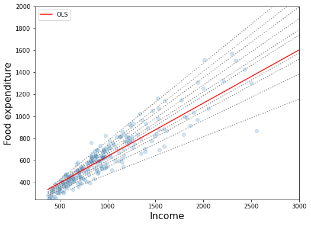

```python
# code taken from statsmodel documentation:
# https://www.statsmodels.org/dev/examples/notebooks/generated/quantile_regression.html

x = np.arange(engle_data.income.min(), engle_data.income.max(), 50)
get_y = lambda a, b: a + b * x

fig, ax = plt.subplots(figsize=(8, 6))

for i in range(models.shape[0]):
    y = get_y(models.a[i], models.b[i])
    ax.plot(x, y, linestyle="dotted", color="grey")

y = get_y(ols["a"], ols["b"])

ax.plot(x, y, color="red", label="OLS")
ax.scatter(engle_data.income, engle_data.food, alpha=0.2)
ax.set_xlim((240, 3000))
ax.set_ylim((240, 2000))
legend = ax.legend()
ax.set_xlabel("Income", fontsize=16)
ax.set_ylabel("Food expenditure", fontsize=16)
```

# Part 3: vector quantile regression

## References

- Ekeland, Galichon and Henry (2012). Comonotonic measures of multivariate risks. *Mathematical Finance*.
- Carlier, Galichon and Chernozhukov (2016). Vector quantile regression: an optimal transport approach. *Annals of Statistics*.
- Carlier, Galichon and Chernozhukov (2017). Vector quantile regression beyond correct specification. *Journal of Multivariate Analysis*.
- Chernozhukov, Galichon, Hallin and Henry (2017). Monge-Kantorovich Depth, Quantiles, Ranks and Signs. *Annals of Statistics*.
- Carlier, Chernozhukov, De Bie, and G (2021). Vector quantile regression and optimal transport, from theory to numerics. Forthcoming, *Empirical Economics*.

### Classical quantile regression and duality

- Recall  
  $\begin{array} \min_{P\geq0,N\geq0,\beta} & \mathbb{E}\left[ \tau P+\left( 1-\tau\right) N\right] \\ s.t.~ & P-N=Y-X^{\top}\beta~\left[ V\right] \end{array}$  
  where  
  $P=\left( Y-X^{\top}\beta\right) ^{+}$ and $N=\left( Y-X^{\top} \beta\right) ^{-}$,
- Eliminate $N$ and rewrite  
  $\begin{array} ~\min_{P\geq0,\beta} & \mathbb{E}\left[ P+\left( 1-\tau\right) X^{\top} \beta \right] \\ s.t.~ & P + X^{\top}\beta\geq Y ~\left[ V\right] \end{array}$  
  which we call the *dual* problem.
- The corresponding primal problem is  
  $\begin{array} & \max_{V\geq 0} & \mathbb{E}\left[ YV\right] \\ s.t.~ & V\leq1~\left[ P\geq0\right] \\ & \mathbb{E}\left[ VX\right] =\left( 1-\tau\right) \mathbb{E}\left[ X\right] ~\left[ \beta\right] \end{array}$

### Complementary slackness

- Let $V\left( \tau\right) $ and $\beta\left( \tau\right) $ be solutions to the above program. Complementary slackness yields  
  $\left\{\begin{array} ~Y-X^{\top}\beta\left( \tau\right) & <0\implies V\left( \tau\right) =0\\ Y-X^{\top}\beta\left( \tau\right) & >0\implies V\left( \tau\right) =1 \end{array}\right.$  
  therefore  
  $1\left\{ Y>X^{\top}\beta\left( \tau\right) \right\} \leq V\left( \tau\right) \leq1\left\{ Y\geq X^{\top}\beta\left( \tau\right) \right\}.$
- Assume $\left( X,Y\right) $ has a continuous distribution,. Then for any $\beta$, $\Pr\left( Y-X^{\top}\beta=0\right) =0$, and therefore one has almost surely  
  $V\left( \tau\right) =1\left\{ Y\geq X^{\top}\beta\left( \tau\right) \right\}.$

### Quantile curve regression

- Consider now solving the problems above for all values of $\tau$ *all at once*. We can write:  
  $\max_{V\left( .\right) \geq 0 }\int_{0}^{1}\mathbb{E}\left[ YV\left( \tau\right) \right] d\tau$  
  s.t.  
  $V\left( \tau\right) \leq1~\left[ P\left( \tau\right) \geq0\right] $  
  $ \mathbb{E}\left[ V\left( \tau\right) X\right] =\left( 1-\tau\right) \mathbb{E}\left[ X\right] ~\left[ \beta\left( \tau\right) \right]$
- The problem has dual  
  $\begin{array} ~\min_{P\geq0,\beta} & \int_{0}^{1}\mathbb{E}\left[ P\left( \tau\right) +\left( 1-\tau\right) X^{\top}\beta\left( \tau\right) \right] d\tau\\ s.t.~ & P\left( \tau\right) \geq Y-X^{\top}\beta\left( \tau\right) ~\left[ V\left( \tau\right) \right] \end{array}$
- The solution to these problems are the same as the solutions to each of the previous problem -- the contraints don't interfere.
- Sample version:  
  $\begin{array} ~\max_{V_{ti}\geq 0} & \frac{1}{I}\sum_{t,i} V_{ti}Y_{i}\\ s.t.~ & V_{ti}\leq 1\\ & \frac{1}{I}\left( VX\right) _{tk}=\left( 1-\tau _{t}\right) \bar{x}_{k}% \left[ \beta \right] \end{array}$
- In matrix terms, this is  
  $\begin{array} ~\max_{V \geq 0} & \frac{1}{I}1^\top_T V Y\\ s.t.~ & V\leq 1\\ & \frac{1}{I}\left( VX\right) =\left( 1-\tau \right) \bar{x}^\top \left[ \beta \right] \end{array}$
- After vectorization $v=vec(V)$  
  $\begin{array} ~\max_{v \geq 0} & \frac{1}{I}\left( 1_{T}\otimes Y\right) ^{\top }v\\ s.t.~ & V\leq 1\\ & \frac{1}{I}\left( I_{T}\otimes X^{\top }\right) v=vec\left( \left( 1-\tau \right) \bar{% x}^{\top }\right) \end{array}$

Code this as:

```python
Y_i_1 = food.reshape((-1,1))
nbt=21
τ_t_1 = np.linspace(0,1,nbt).reshape((-1,1))
A = spr.kron(spr.identity(nbt),X_i_k.T) / nbi
obj = np.kron(np.ones((nbt,1)),Y_i_1).T / nbi
xbar_1_k = X_i_k.mean(axis = 0).reshape((1,-1))
rhs = ((1-τ_t_1) * xbar_1_k).flatten()
qrs_lp=grb.Model()
qrs_lp.setParam( 'OutputFlag', False )
v = qrs_lp.addMVar(shape=nbi*nbt, name="v",lb=0,ub=1)
qrs_lp.setObjective(obj @ v , grb.GRB.MAXIMIZE)
qrs_lp.addConstr(A @ v == rhs)
qrs_lp.optimize()

βqrs_t_k = np.array(qrs_lp.getAttr('pi')).reshape((nbt,nbk))
βqrs_t_k[10,:]
```

```
array([81.48614818,  0.56017469])
```

### Quantile curve regression under dual monotonicity constraint

- Koenker and Ng (2005) consider imposing the monotonicity constraint of the estimated quantile curves. Thus, they impose a constraint on the dual, namely:  
  $X^{\top}\beta\left( \tau\right) \geq X^{\top}\beta\left( \tau^{\prime}\right) $ for $\tau\geq\tau^{\prime}$,  
  that is  
  $\begin{array} ~\min_{P\geq0,N\geq0,\beta} & \int_{0}^{1}\mathbb{E}\left[ P\left( \tau\right) +\left( 1-\tau\right) X^{\top}\beta\left( \tau\right) \right] d\tau\\ s.t.~ & P\left( \tau\right) -N\left( \tau\right) =Y-X^{\top}\beta\left( \tau\right) ~\left[ V\left( \tau\right) \right] \\ & X^{\top}\beta\left( \tau\right) \geq X^{\top}\beta\left( \tau^{\prime }\right) ,~\tau\geq\tau^{\prime}% \end{array}$
- This is the most natural approach to solve the non-monotonicity problem. However, it does not leads to a simple duality.

### Quantile curve regression under primal monotonicity constraint

- By contrast, [CCG]'s vector quantile regression approach imposes the constraint that the primal variable  
  $\tau\rightarrow V\left( \tau\right) $  
  should be nonincreasing. This is justified by the fact that  
  $V\left( \tau\right) =1\left\{ Y\geq X^{\top}\beta\left( \tau\right) \right\} $,  
  so  
  $ X^{\top} \beta\left( \tau\right) \text{ nondecreasing in } \tau \implies V\left( \tau\right) $ nonincreasing.
- Therefore, we let consider the program \begin{align*} & \max_{V\left( \tau\right) }\int_{0}^{1}\mathbb{E}\left[ YV\left( \tau\right) \right] d\tau\\ s.t.~ & V\left( \tau\right) \geq0~\left[ N\left( \tau\right) \geq0\right] \\ & V\left( \tau\right) \leq1~\left[ P\left( \tau\right) \geq0\right] \\ & \mathbb{E}\left[ V\left( \tau\right) X\right] =\left( 1-\tau\right) \mathbb{E}\left[ X\right] ~\left[ \beta\left( \tau\right) \right] \\ & V\left( \tau\right) \leq V\left( \tau^{\prime}\right) ,~\tau\geq \tau^{\prime}% \end{align*}

### Primal monotonicity constraint, sample version

- Consider $\tau_{1}=0<...<\tau_{T}\leq1$ and let $\bar{x}$ be the $1\times K$ row vector whose $k$-th entry is $\mathbb{E}\left[ X_{k}\right] $.  
  One has \begin{align*} & \max_{V_{ti}\geq0}\frac{1}{I}\sum_{\substack{1\leq i\leq I\\1\leq t\leq T}}V_{ti}% Y_{i}\\ & V_{ti}\leq1\\ & \frac{1}{I}\sum_{1\leq i\leq I}V_{ti}X_{ik}=\left( 1-\tau_{t}\right) \bar{x}_{k}\\ & V_{\left( t+1\right) i}\leq V_{ti} \end{align*}
- As $\tau_{1}=0$, one has necessarly $V_{1i}=1$ and the program becomes \begin{align*} & \max_{V_{ti}}\frac{1}{I}\sum_{\substack{1\leq i\leq I\\1\leq t\leq T}}V_{ti}Y_{i}\\ & V_{1i}=1\\ & \frac{1}{I}\sum_{1\leq i\leq I}V_{ti}X_{ik}=\left( 1-\tau_{t}\right) \bar{x}_{k}\\ & V_{t1}\geq V_{t2}\geq...\geq V_{t\left( m-1\right) }\geq V_{T,i}\geq0. \end{align*}

### Matrix notations

- Let $\tau$ be the $T\times1$ row matrix with entries $\tau_{k}$.
- Let $D$ be a $T\times T$ matrix defined as $$ D= \begin{pmatrix} 1 & 0 & 0 & \cdots & 0 & 0\\ -1 & 1 & 0 & \ddots & \vdots & \vdots\\ 0 & -1 & 1 & \ddots & 0 & 0\\ \vdots & \ddots & \ddots & \ddots & 0 & 0\\ \vdots & & 0 & -1 & 1 & 0\\ 0 & & 0 & 0 & -1 & 1 \end{pmatrix} $$ we have $V^{\top}D\geq0$ if and only if $$V_{1i}\geq V_{2i}\geq...\geq V_{\left( T-1\right) i}\geq V_{Ti}\geq0.$$
- One can write \begin{align*} & \frac{1}{I}\max_{V}1_{T}^{\top}VY\\ & \frac{1}{I}VX=\left( 1_{T}-\tau\right) \bar{x}\\ & V^{\top}D1_{T}=1_{I}\\ & V^{\top}D\geq0 \end{align*}
- Thus, setting  
  $\pi=D^{\top}V/I$, and $U=D^{-1}1_{I}$, $\mu=D^{\top}\left( 1_{T}-\tau\right) $, and $p=1_{I}/I$,  
  one has  
  \begin{align*} & \max_{\pi}U^{\top}\pi Y\\ & \pi X=\mu\bar{x}\\ & \pi^{\top}1_{T}=p\\ & \pi\geq0 \end{align*}
- Assume that the first entry of $X$ is one. One has that if $\pi$ satisfies the constraints, then $$\sum_{i=1}^{I}\pi_{ti}=\mu_{t}\text{ and }\sum_{t=1}^{T}\pi_{ti}=p_{i}$$ thus $\pi$ can be thought of as a joint probability on $\tau$ and $X$.
- One has \begin{align*} & \max_{\pi\geq0}\sum_{\substack{1\leq t\leq T\\1\leq i\leq I}}\pi_{ti} U_{t}Y_{i}\\ & \sum_{1\leq i\leq I}\pi_{ti}X_{ik}=\mu_{t}\bar{x}_{k}\\ & \sum_{1\leq t\leq T}\pi_{ti}=p_{i}% \end{align*}

### Computation

- Recall the problem to compute \begin{align*} & \max_{\pi\geq0}U^{\top}\pi Y\\ & \pi X=\mu\bar{x}\\ & \pi^{\top}1_{T}=p \end{align*} which we sill vectorize using $vec\left( A\pi B\right) =\left( A \otimes B^{\top }\right) vec\left( \pi\right) $ so that the constraint becomes $$ \begin{pmatrix} I_{T}\otimes X^{\top}\\ 1_{T}^{\top} \otimes I_{I} \end{pmatrix} vec\left( \pi\right) =\binom{vec\left( \mu\bar{x}\right) }{p}% $$
- There are $IT$ primal variables and $KT+I$ constraints.
- Computation is done with a linear programming solver like Gurobi. Large-scale linear programming solvers make use of sparsity of constraint matrix. However, if dimension of $Y$ is larger, $T$ will need to be large.

### Recovering the $\beta$

- $\beta$ is the vector of Lagrange multipliers of the constraint $ \frac{1}{I}V X= \left( 1_{T}-\tau \right) \bar{x} $ in the former problem.
- Let $\psi$ be the vector of Lagrange multipliers of the constraint $\pi X-\mu \bar{x}$ in the latter problem.
- We have $\beta = D \psi$. Indeed:  
  $\left( \pi X-\mu \bar{x}\right) ^{\top }\psi =0$  
  thus  
  $\left( \frac{1}{I}D^{\top }V X-D^{\top }\left( 1_{T}-\tau \right) \bar{x}% \right) ^{\top }\psi =0$  
  and therefore  
  $\left( \frac{1}{I}V X-\left( 1_{T}-\tau \right) \bar{x}\right) ^{\top }D\psi =0$
- Compute in the following manner:

```python
D_t_t = spr.diags([1, -1], [ 0, -1], shape=(nbt, nbt))

U_t_1 = np.linalg.inv(D_t_t.toarray()) @ np.ones( (nbt,1))
μ_t_1 = D_t_t.T @ (np.ones((nbt,1)) - τ_t_1)

A1 = spr.kron(spr.identity(nbt),X_i_k.T)
A2 = spr.kron(np.array(np.repeat(1,nbt)),spr.identity(nbi))
A = spr.vstack([A1, A2])
rhs = np.concatenate( [(μ_t_1 * xbar_1_k).flatten(), np.ones(nbi)/nbi])
obj = np.kron(U_t_1, Y_i_1).T
vqr_lp=grb.Model()
pi = vqr_lp.addMVar(shape=nbi*nbt, name="pi")
vqr_lp.setParam( 'OutputFlag', False )
vqr_lp.setObjective( obj @ pi, grb.GRB.MAXIMIZE)
vqr_lp.addConstr(A @ pi == rhs)
vqr_lp.optimize()

ϕ_t_k = np.array(vqr_lp.getAttr('pi'))[0:(nbt*nbk)].reshape((nbt,nbk))

βvqr_t_k = D_t_t.toarray() @ ϕ_t_k

βvqr_t_k[10,:]
```

```
array([81.48614818,  0.56017469])
```

## Vector quantile regression in the continuous case

- This rewrites as a *Vector quantile regression* (yet for now in the scalar case), introduced in [CCG16] \begin{align*} \max_{\pi} & \mathbb{E}_{\pi}\left[ UY\right] \\ s.t. & U\sim\mu\\ & \left( X,Y\right) \sim P\\ & \mathbb{E}\left[ X|U\right] =\mathbb{E}\left[ X\right] \end{align*}
- This is an extension of the optimal transport problem of Monge-Kantorovich. As a matter of fact, when $X$ is restricted to the constant, this is *exactly* an optimal transport problem.

### Vector quantile regression, primal problem

- Recall our previous problem \begin{align*} \max_{\pi} & \mathbb{E}_{\pi}\left[ UY\right] \\ s.t. & U\sim\mu\\ & \left( X,Y\right) \sim P\\ & \mathbb{E}\left[ X|U\right] \sim\mathbb{E}\left[ X\right] \end{align*} and replace mean-independence by independence; one has \begin{align*} \max_{\pi} & \mathbb{E}_{\pi}\left[ UY\right] \\ s.t. & U\sim\mu\\ & \left( X,Y\right) \sim P\\ & X {\perp\!\!\!\perp}U \end{align*}
- The solution to the latter problem is simply  
  $U=F_{Y|X}\left( Y|X\right)$  
  which yields the nonparametric conditional quantile representation  
  $Y=F_{Y|X}^{-1}\left( U|X\right).$

### Vector quantile regression, dual problem

- The dual problem yields \begin{align*} \min_{\psi,b} & \mathbb{E}_{P}\left[ \psi\left( X,Y\right) \right] +\bar{x}^{\top}\mathbb{E}_{\mu}\left[ b\left( U\right) \right] \\ s.t.~ & \psi\left( x,y\right) +x^{\top}b\left( \tau\right) \geq\tau y,~\forall x,y,\tau \end{align*}
- Optimality of $\left( \psi,b\right) $ yields $$ \psi\left( x,y\right) =\sup_{\tau\in\left[ 0,1\right] }\left\{ \tau y-x^{\top}b\left( \tau\right) \right\} $$ which yields, if $b$ is differentiable, $$ Y=X^{\top}\beta\left( U\right) $$ where $(U,X,Y)$ are the solutions to the primal problem and $\beta\left( \tau\right) =b^{\prime}\left( \tau\right) $.

### Multivariate case

- Vector quantile regression yields a natural way to extend classical quantile regression to the case when the dependent variable is multivariate. If $Y$ is valued in $\mathbb{R}^{d}$, one may take $\tau$ in $\mathbb{R}^{d}$, $\mu=\mathcal{U}\left( \left[ 0,1\right] ^{d}\right) $. We replace the product $\tau$ by the scalar product $\tau^{\top}\beta\left( U\right) $, and the analysis goes unmodified.
- We get a nice tensorization of vector quantile regression that way: when the components of $Y$ are independent, the previous propal amounts to running the scalar version component by component.